# R & Python Analysis

3/16/2022

### Introduction

On March 16, 2022, [Tal Mizrachi](https://www.linkedin.com/in/talnmizrachi/) (The amazing [Analysis Paralysis](https://www.facebook.com/go.analysis.paralysis)) & [Amit Levinson](https://amitlevinson.com/) live streamed an R vs/and python data analysis session.

Follow along with the [full recording](https://www.youtube.com/watch?v=oO8MZWk07q0&feature=youtu.be)

Solved it? Enjoyed? Have any feedback? Let us know! We’d love to hear!

##### Loading libraries

```python
import pandas as pd
import numpy as np
import os
import matplotlib.pyplot as plt
import seaborn as sns
```

```r
library(purrr)
library(dplyr)
library(readr)
library(tidyr)
library(ggplot2)
library(tidytext)
library(reticulate)
```

### Questions

#### 1. Load the files into memory and combine them into a single Dataframe

**Solution**

##### Python

```python
all_files = []
for file in os.listdir("split_data/"):
    if not file.endswith("csv"):
        continue
    all_files.append(pd.read_csv("split_data/"+file))

df = pd.concat(all_files, ignore_index=True)

df
```

```
##       owner_id    age gender  ...  dog_gender    dog_color     dog_dob
## 0       124913  41-50      w  ...           m    saufarben  1996-11-10
## 1        84494  61-70      w  ...           w  schwarz/rot  1997-08-10
## 2        85293  81-90      w  ...           w  beige/weiss  1997-09-10
## 3        80204  51-60      w  ...           m   dreifarbig  1998-08-10
## 4        80399  61-70      w  ...           m     tricolor  1998-08-10
## ...        ...    ...    ...  ...         ...          ...         ...
## 7150    135725  31-40      w  ...           w   gelb/weiss  2016-03-10
## 7151    135726  11-20      w  ...           w      schwarz  2016-09-10
## 7152    135728  31-40      w  ...           w   vierfarbig  2016-02-10
## 7153    135731  21-30      m  ...           m      schwarz  2016-12-10
## 7154     67272  31-40      w  ...           w     tricolor  2017-05-10
##
## [7155 rows x 14 columns]
```

##### R

```r
files <- paste0("split_data/",list.files(path = "split_data/"))
dogs <- map_dfr(files, read_csv, col_types = cols())

dogs
```

```
## # A tibble: 7,155 × 14
##    owner_id age   gender city_district quarter primary_breed           is_hybrid
##       <dbl> <chr> <chr>          <dbl>   <dbl> <chr>                   <chr>
##  1   124913 41-50 w                 11     115 Spitz                   Mischling
##  2    84494 61-70 w                 10     102 Dachshund               <NA>
##  3    85293 81-90 w                 11     115 Malteser                Mischling
##  4    80204 51-60 w                 11     111 Appenzeller             <NA>
##  5    80399 61-70 w                 12     123 Appenzeller             Mischling
##  6    82293 71-80 w                  2      24 Mischling klein         <NA>
##  7    82452 61-70 w                 10     102 Dachshund               <NA>
##  8    82452 61-70 w                 10     102 Dachshund               <NA>
##  9    83136 71-80 m                  3      31 Mischling klein         <NA>
## 10    83476 61-70 w                 11     119 West Highland White Te… <NA>
## # … with 7,145 more rows, and 7 more variables: secondary_breed <chr>,
## #   is_secondary_hybrid <lgl>, breed_type <chr>, dog_yob <dbl>,
## #   dog_gender <chr>, dog_color <chr>, dog_dob <date>
```

#### 2. Describe the data using a summary function of sort

**Solution**

##### Python

```python
df.describe(percentiles=[0.2,0.8])
```

```
##             owner_id  city_district  ...  is_secondary_hybrid      dog_yob
## count    7155.000000    7154.000000  ...                  0.0  7155.000000
## mean   105854.243326       7.413195  ...                  NaN  2009.803215
## std     21260.952718       3.261187  ...                  NaN     4.115384
## min       126.000000       1.000000  ...                  NaN  1996.000000
## 20%     87256.000000       4.000000  ...                  NaN  2006.000000
## 50%    105784.000000       8.000000  ...                  NaN  2010.000000
## 80%    126879.800000      11.000000  ...                  NaN  2014.000000
## max    135731.000000      12.000000  ...                  NaN  2017.000000
##
## [8 rows x 5 columns]
```

##### R

```r
skimr::skim(dogs)
```

Data summary

| Name | dogs |
| --- | --- |
| Number of rows | 7155 |
| Number of columns | 14 |
| _______________________ |  |
| Column type frequency: |  |
| character | 8 |
| Date | 1 |
| logical | 1 |
| numeric | 4 |
| ________________________ |  |
| Group variables | None |

**Variable type: character**

| skim_variable | n_missing | complete_rate | min | max | empty | n_unique | whitespace |
| --- | --- | --- | --- | --- | --- | --- | --- |
| age | 1 | 1.00 | 5 | 6 | 0 | 9 | 0 |
| gender | 0 | 1.00 | 1 | 1 | 0 | 2 | 0 |
| primary_breed | 0 | 1.00 | 3 | 34 | 0 | 304 | 0 |
| is_hybrid | 6537 | 0.09 | 9 | 9 | 0 | 1 | 0 |
| secondary_breed | 6612 | 0.08 | 4 | 30 | 0 | 118 | 0 |
| breed_type | 0 | 1.00 | 1 | 2 | 0 | 3 | 0 |
| dog_gender | 0 | 1.00 | 1 | 1 | 0 | 2 | 0 |
| dog_color | 0 | 1.00 | 3 | 28 | 0 | 169 | 0 |

**Variable type: Date**

| skim_variable | n_missing | complete_rate | min | max | median | n_unique |
| --- | --- | --- | --- | --- | --- | --- |
| dog_dob | 0 | 1 | 1996-11-10 | 2017-05-10 | 2010-08-10 | 226 |

**Variable type: logical**

| skim_variable | n_missing | complete_rate | mean | count |
| --- | --- | --- | --- | --- |
| is_secondary_hybrid | 7155 | 0 | NaN | : |

**Variable type: numeric**

| skim_variable | n_missing | complete_rate | mean | sd | p0 | p25 | p50 | p75 | p100 | hist |
| --- | --- | --- | --- | --- | --- | --- | --- | --- | --- | --- |
| owner_id | 0 | 1 | 105854.24 | 21260.95 | 126 | 88587.5 | 105784 | 124634.5 | 135731 | ▁▁▁▇▇ |
| city_district | 1 | 1 | 7.41 | 3.26 | 1 | 5.0 | 8 | 10.0 | 12 | ▅▂▅▅▇ |
| quarter | 1 | 1 | 76.70 | 33.03 | 4 | 51.0 | 81 | 102.0 | 123 | ▂▃▆▅▇ |
| dog_yob | 0 | 1 | 2009.80 | 4.12 | 1996 | 2007.0 | 2010 | 2013.0 | 2017 | ▁▃▆▇▇ |

##### 3. What are the top 10 most common colors? Each color should be counted separately, i.e. black/brown should be counted as 1 black, 1 brown.

**Solution**

###### Python

```python
melted = df['dog_color'].str.split("/", expand=True).melt().copy()

melted['value'].value_counts()
```

```
## schwarz                2349
## weiss                  2207
## braun                  1836
## tricolor                696
## beige                   622
##                        ...
## bicolor                   1
## schwarz melliert          1
## hirschrot mit Maske       1
## marronschimmel            1
## rotblond                  1
## Name: value, Length: 89, dtype: int64
```

###### R

```r
dogs %>%
  transmute(
    new_color = strsplit(dog_color, split = "/")
    ) %>%
  unnest() %>%
  count(new_color, sort = T)
```

```
## # A tibble: 89 × 2
##    new_color     n
##    <chr>     <int>
##  1 schwarz    2349
##  2 weiss      2207
##  3 braun      1836
##  4 tricolor    696
##  5 beige       622
##  6 rot         368
##  7 grau        282
##  8 tan         228
##  9 hellbraun   170
## 10 black       160
## # … with 79 more rows
```

##### 4. What are the top 10 most common primary breeds by dog gender? Visualize it using a corresponding bar plot

**Solution**

###### Python

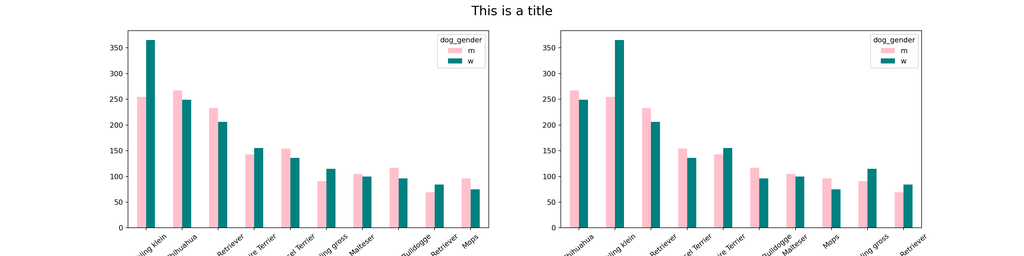

```python
main_table = df[['dog_gender','primary_breed']].pivot_table(index='primary_breed', columns='dog_gender', aggfunc=len).copy()


sorted_by_w = main_table.sort_values('w', ascending=False).head(10).copy()
sorted_by_m = main_table.sort_values('m', ascending=False).head(10).copy()


fig, axes = plt.subplots(1,2)

fig.suptitle("This is a title", fontsize=18)

sorted_by_w.plot(kind='bar', rot=40, color=["pink", "teal"], ax=axes[0], figsize=(20,5))
sorted_by_m.plot(kind='bar', rot=40, color=["pink", "teal"], ax=axes[1], figsize=(20,5))
```

###### R

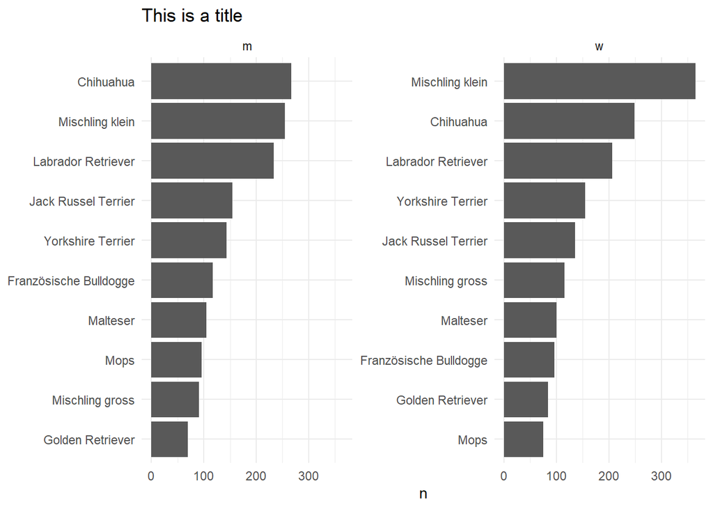

```r
dogs %>%
  count(dog_gender, primary_breed, sort = T) %>%
  group_by(dog_gender) %>%
  slice(1:10) %>%
  ggplot(aes(y = reorder_within(primary_breed, by =  n, within = dog_gender), x = n)) +
  geom_col() +
  facet_wrap(vars(dog_gender), scales = "free_y") +
  scale_y_reordered() +
  labs(y = NULL, title = "This is a title")+
  theme_minimal()
```

#### 5. Who (owner) has dogs with the largest age gap between them? What’s the gap value?

**Solution**

##### Python

```python
df['dog_dob'] = pd.to_datetime(df['dog_dob'])
gb = df[['owner_id', 'dog_dob']].groupby('owner_id').agg([min, max])

gb.columns = ["_".join(list(x)) for x in gb.columns]

gb['diff'] = (gb['dog_dob_max']-gb['dog_dob_min']).dt.days

gb.sort_values('diff').tail(1)
```

```
##          dog_dob_min dog_dob_max  diff
## owner_id
## 87158     2000-04-10  2015-10-10  5661
```

##### R

```r
dogs %>%
  group_by(owner_id) %>%
  filter(
    n() > 1,
    dog_dob == min(dog_dob) | dog_dob == max(dog_dob)
  ) %>%
  select(owner_id, dog_dob) %>%
  arrange(owner_id, dog_dob) %>%
  summarise(
    timediff = difftime(dog_dob, time2 = lag(dog_dob), units = "days")
  ) %>%
  fill(timediff, .direction = "up") %>%
  arrange(-timediff)
```

```
## # A tibble: 1,153 × 2
## # Groups:   owner_id [576]
##    owner_id timediff
##       <dbl> <drtn>
##  1    87158 5661 days
##  2    87158 5661 days
##  3    88250 5265 days
##  4    88250 5265 days
##  5   100112 5234 days
##  6   100112 5234 days
##  7   109472 4932 days
##  8   109472 4932 days
##  9   128461 4932 days
## 10   128461 4932 days
## # … with 1,143 more rows
```

**Another solution suggested by [Adi Sarid](https://adisarid.github.io/)**

```r
dogs %>%
  group_by(owner_id) %>%
  summarise(age_gap = max(dog_dob) - min(dog_dob)) %>%
  arrange(desc(age_gap))
```

#### 6. Save the Dataframe into an excel file where each sheet is a different age-group of owners

**Solution**

##### Python

```python
writer = pd.ExcelWriter("dogs_by_owner_age_python.xlsx")

for age in df['age'].fillna("None").unique():
    temp_df = df[df['age']==age].copy()
    temp_df.to_excel(writer, sheet_name=age)

writer.save()
```

##### R

```r
dogs %>%
  split(.$age) %>%
  writexl::write_xlsx(path = "dogs_by_owners_age.xlsx")
```

##### Output

[figure not shown]